# Example application: parameter contributions to MCI vs HC classification

Thomas Wilschut Last updated: 2026-10-01

- Setup and helpers
  - Helpers
- Greedy forward selection with refitting
  - Data preparation
  - Greedy selection: person-average criterion
  - Plot: person-average greedy selection
  - Single-session AUC from person-average selection path
  - Greedy selection: single-session criterion (steps 3–5)
  - Plot: combined figure (person-average + single-session)
  - Summary statistics for paper
- Worst-session vs. mean aggregation (Reviewer 2, comment 8)
- Baseline: classification from raw behavioural features (Reviewer 2, comments 5 & 9)
  - Compute raw behavioural features
  - Classification AUC from raw behavioural features
  - Comparison to the model-based classification result
- Session info

# Setup and helpers

The classification analysis below reports performance as a bootstrap-corrected AUC, to guard against the optimism of evaluating a model on the same data it was fit to. We first set up the parameter lookups and the bootstrap helper used throughout.

## Helpers

A few display lookups (full parameter names and a consistent colour palette) that are reused across the plots below.

```r
# ── Shared constants ──────────────────────────────────────────────────────────
PARAM_COL <- c(phi = "phi", tau = "tau", s = "s", F = "lf", ter = "ter")

param_display <- c(
  phi = "Speed of Forgetting",
  tau = "Retrieval threshold",
  s   = "Activation noise",
  F   = "Latency factor",
  ter = "Non-retrieval time"
)

param_cols <- setNames(
  pal_aaas()(5),
  c("Speed of Forgetting", "Retrieval threshold", "Activation noise",
    "Latency factor", "Non-retrieval time")
)
```

The idea is to first compute the apparent AUC (the model evaluated on the same data it was fit to, which is optimistically biased), then estimate that optimism by repeatedly refitting on bootstrap resamples and re-evaluating on the original data; the corrected AUC subtracts the mean optimism. `bootstrap_auc_corrected()` implements this and is the function used inside the greedy selection below.

```r
# ── Bootstrap-corrected AUC (general, used in greedy selection) ───────────────
bootstrap_auc_corrected <- function(outcome, predictors_df,
                                    n_boot = 500, seed = 42) {
  set.seed(seed)
  data   <- data.frame(outcome = outcome, predictors_df)
  n      <- nrow(data)
  params <- names(predictors_df)

  fmla <- if (length(params) == 1) NULL
          else as.formula(paste("outcome ~", paste(params, collapse = " + ")))

  if (is.null(fmla)) {
    roc_app <- roc(data$outcome, data[[params]], direction = "auto", quiet = TRUE)
    p_app   <- data[[params]]
  } else {
    fit_full <- glm(fmla, data = data, family = binomial())
    p_app    <- predict(fit_full, type = "response")
    roc_app  <- roc(data$outcome, p_app, direction = "auto", quiet = TRUE)
  }
  auc_app <- as.numeric(auc(roc_app))

  boot_aucs <- replicate(n_boot, {
    idx    <- sample(n, n, replace = TRUE)
    b_data <- data[idx, ]
    if (length(unique(b_data$outcome)) < 2) return(NA_real_)
    if (is.null(fmla)) {
      p_orig <- data[[params]]
    } else {
      fit_b <- tryCatch(glm(fmla, data = b_data, family = binomial()),
                        error = function(e) NULL)
      if (is.null(fit_b)) return(NA_real_)
      p_orig <- predict(fit_b, newdata = data, type = "response")
    }
    tryCatch(
      as.numeric(auc(roc(data$outcome, p_orig, direction = "auto", quiet = TRUE))),
      error = function(e) NA_real_
    )
  })

  optimism      <- auc_app - mean(boot_aucs, na.rm = TRUE)
  auc_corrected <- auc_app - optimism

  list(
    auc_apparent  = auc_app,
    auc_corrected = auc_corrected,
    auc_lo        = quantile(boot_aucs, 0.025, na.rm = TRUE),
    auc_hi        = quantile(boot_aucs, 0.975, na.rm = TRUE)
  )
}
```

# Greedy forward selection with refitting

To see which parameters carry the diagnostic signal, we perform a greedy forward selection: starting from no free parameters, at each step we add the parameter that most improves classification. Crucially, for each candidate parameter set the data are refit with the non-selected parameters held fixed at their population defaults, so that each model genuinely uses only the information in its selected parameters.

## Data preparation

For the refitting analysis we reload the raw per-trial data and apply the same filtering rules as Hake et al. (drop fact sequences with fewer than three encounters, or with response times below 300 ms or above 15 s), and code the outcome as MCI = 1 / HC = 0.

```r
future::plan(future::multisession, workers = future::availableCores() - 1)

source(here::here("R", "sim-mle.R"))
d <- fread(here::here("data", "processed", "hake2026.csv"))

min_rt             <- 0.3
max_rt             <- 15
min_reps_per_fact  <- 3

fact_sequences <- split(d, by = c("user_id", "session_id", "fact_id"))
fact_sequences_filtered <- fact_sequences[
  map_lgl(fact_sequences, ~ nrow(.x) >= min_reps_per_fact &&
            min(.x$rt) >= min_rt && max(.x$rt) <= max_rt)
]

d_filtered <- rbindlist(fact_sequences_filtered)
setorder(d_filtered, user_id, start_time)

clinical_df <- unique(d_filtered[, .(user_id, clinical_status)])[
  , outcome := as.integer(clinical_status == "MCI")
]
```

## Greedy selection: person-average criterion

`greedy_select_auc()` performs the forward selection: starting from no free parameters, at each step it refits every session with each remaining candidate added to the already-selected set, aggregates the session fits to person-level means, and keeps the candidate that yields the highest bootstrap-corrected AUC. It returns both the per-step summary and the underlying fits (the latter are reused below to evaluate the single-session criterion without refitting).

```r
# ── Aggregate session-level fits to person-level means ────────────────────────
person_means <- function(fits_dt, free_params, clinical_df) {
  cols <- PARAM_COL[free_params]
  cols <- cols[cols %in% names(fits_dt)]
  agg  <- fits_dt[, lapply(.SD, mean, na.rm = TRUE),
                  by = .(user_id), .SDcols = cols]
  merge(agg, clinical_df, by = "user_id")
}

# ── Greedy forward selection (person-average AUC criterion) ───────────────────
greedy_select_auc <- function(d_filtered,
                              all_params = c("phi", "tau", "s", "F", "ter"),
                              n_boot     = 500,
                              full_iter  = 100) {

  clinical_df <- unique(d_filtered[, .(user_id, clinical_status)])[
    , outcome := as.integer(clinical_status == "MCI")
  ]
  d_sessions <- split(d_filtered, by = "session_id")

  fit_sessions <- function(free_params) {
    message("  Fitting ", length(d_sessions), " sessions with free: {",
            paste(free_params, collapse = ", "), "} ...")
    results <- future_map(d_sessions, function(d_i) {
      fit_i <- fit_one_learner(d_i, free_params = free_params,
                               full_iter = full_iter)[.N]
      if (is.null(fit_i) || nrow(fit_i) == 0) return(data.table())
      fit_i[, `:=`(user_id         = d_i$user_id[1],
                   clinical_status = d_i$clinical_status[1],
                   session_id      = d_i$session_id[1])]
      fit_i
    }, .options = furrr_options(seed = TRUE), .progress = interactive())
    results <- results[!vapply(results, function(x) is.null(x) || nrow(x) == 0,
                               logical(1))]
    rbindlist(results, fill = TRUE)
  }

  selected  <- character(0)
  remaining <- all_params
  log_rows  <- list()
  all_fits  <- list()

  for (step in seq_along(all_params)) {
    message("\n=== Step ", step, ": testing ", length(remaining), " candidate(s) ===")
    step_rows <- list()

    for (candidate in remaining) {
      trial_params <- c(selected, candidate)
      message("  Candidate: {", paste(trial_params, collapse = ", "), "}")

      fits_dt <- fit_sessions(trial_params)
      if (nrow(fits_dt) == 0) { message("  WARNING: no fits returned"); next }

      pm        <- person_means(fits_dt, trial_params, clinical_df)
      pred_cols <- PARAM_COL[trial_params]
      pred_cols <- pred_cols[pred_cols %in% names(pm)]
      auc_res   <- bootstrap_auc_corrected(pm$outcome, pm[, ..pred_cols],
                                           n_boot = n_boot)

      message(sprintf("    AUC corrected = %.3f [%.3f-%.3f]",
                      auc_res$auc_corrected, auc_res$auc_lo, auc_res$auc_hi))

      step_rows[[candidate]] <- data.table(
        step = step, param_added = candidate, free_params = list(trial_params),
        auc_apparent = auc_res$auc_apparent, auc_corrected = auc_res$auc_corrected,
        auc_lo = auc_res$auc_lo, auc_hi = auc_res$auc_hi, selected = FALSE
      )

      key      <- paste(step, candidate, sep = "_")
      fit_copy <- copy(fits_dt)
      fit_copy[, `:=`(step = step, param_added = candidate,
                      free_params_str = paste(trial_params, collapse = ","))]
      all_fits[[key]] <- fit_copy
    }

    step_dt  <- rbindlist(step_rows)
    best_idx <- which.max(step_dt$auc_corrected)
    best_par <- step_dt$param_added[best_idx]
    step_dt[best_idx, selected := TRUE]

    message(sprintf("  >>> Selected: %s  (AUC = %.3f)",
                    best_par, step_dt$auc_corrected[best_idx]))

    log_rows[[step]] <- step_dt
    selected  <- c(selected, best_par)
    remaining <- setdiff(remaining, best_par)
  }

  list(summary = rbindlist(log_rows),
       learner_fits = rbindlist(all_fits, fill = TRUE))
}
```

```r
# Expensive (refits every session for every candidate); cached and reloaded below.
greedy_auc <- greedy_select_auc(d_filtered)
saveRDS(greedy_auc, here::here("data", "processed", "fits", "greedy_auc_results.rds"))
```

## Plot: person-average greedy selection

This plots the person-average selection path (Figure 10A): the solid line is the selected path, faint points are the non-selected candidates at each step, and the shaded band is the 95% bootstrap CI on the selected path. F is selected first and φ second, after which adding further parameters does not improve classification.

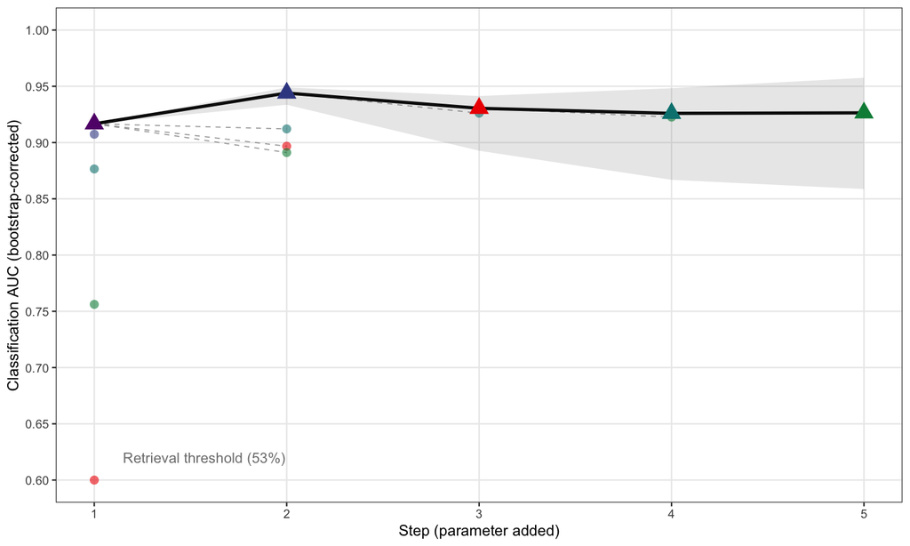

```r
greedy_auc <- readRDS(here::here("data", "processed", "fits", "greedy_auc_results.rds"))

# Backward compatibility: rename alpha -> phi in cached results
if ("alpha" %in% names(greedy_auc$learner_fits)) setnames(greedy_auc$learner_fits, "alpha", "phi")
if ("param_added" %in% names(greedy_auc$learner_fits)) greedy_auc$learner_fits[param_added == "alpha", param_added := "phi"]
if ("param_added" %in% names(greedy_auc$summary))      greedy_auc$summary[param_added == "alpha", param_added := "phi"]
if ("free_params" %in% names(greedy_auc$summary)) {
  greedy_auc$summary[, free_params := lapply(free_params, function(fp) replace(fp, fp == "alpha", "phi"))]
}

summary_dt <- copy(greedy_auc$summary)
summary_dt[, param_label := param_display[param_added]]

selection_path <- summary_dt[selected == TRUE][order(step)]
selection_path[, param_label := param_display[param_added]]

seg_data <- summary_dt[selected == FALSE]
seg_data[, y_from := selection_path$auc_corrected[
  match(step - 1, selection_path$step)
]]

p_auc <- ggplot() +
  geom_segment(
    data = seg_data[!is.na(y_from)],
    aes(x = step - 1, xend = step, y = y_from, yend = auc_corrected,
        color = 'black'),
    linewidth = 0.4, linetype = "dashed", alpha = 0.7
  ) +
  geom_line(data = selection_path,
            aes(x = step, y = auc_corrected),
            linewidth = 1.2, color = "black") +
  geom_ribbon(data = selection_path,
              aes(x = step, ymin = auc_lo, ymax = auc_hi),
              alpha = 0.15, fill = "grey40") +
  geom_point(data = summary_dt[selected == FALSE],
             aes(x = step, y = auc_corrected, color = param_label),
             size = 3, shape = 16, alpha = 0.6) +
  geom_point(data = selection_path,
             aes(x = step, y = auc_corrected, color = param_label),
             size = 5, shape = 17) +
  geom_text(
    data = summary_dt[selected == FALSE & auc_corrected < 0.6],
    aes(x = step + 0.15, y = 0.62,
        label = paste0(param_label, " (",
                       scales::percent(auc_corrected, accuracy = 1), ")"),
        color = 'black'),
    size = 4, hjust = 0, show.legend = FALSE
  ) +
  scale_color_manual(name = "Parameter", values = param_cols) +
  scale_x_continuous(breaks = 1:5) +
  scale_y_continuous(limits = c(0.6, 1),
                     breaks = seq(0.6, 1, by = 0.05),
                     oob = scales::squish) +
  labs(x = "Step (parameter added)",
       y = "Classification AUC (bootstrap-corrected)") +
  theme_bw(base_size = 12) +
  theme(legend.position = "none", panel.grid.minor = element_blank())

p_auc
```

## Single-session AUC from person-average selection path

Compute single-session AUCs for all candidate models fitted during the person-average greedy selection (i.e., same fits, different evaluation criterion).

```r
summary_single <- map_dfr(
  split(greedy_auc$summary, seq_len(nrow(greedy_auc$summary))),
  function(s) {
    fp      <- s$free_params[[1]]
    step_i  <- s$step[[1]]
    param_i <- s$param_added[[1]]

    fits_i    <- greedy_auc$learner_fits[step == step_i & param_added == param_i]
    fits_i    <- merge(fits_i, clinical_df, by = "user_id")
    pred_cols <- unname(PARAM_COL[fp])
    pred_cols <- pred_cols[pred_cols %in% names(fits_i)]

    auc_res <- bootstrap_auc_corrected(
      fits_i$outcome, as.data.frame(fits_i[, ..pred_cols]), n_boot = 500
    )

    data.table(
      step = step_i, param_added = param_i, free_params = list(fp),
      auc_apparent = auc_res$auc_apparent, auc_corrected = auc_res$auc_corrected,
      auc_lo = auc_res$auc_lo, auc_hi = auc_res$auc_hi,
      selected = s$selected[[1]]
    )
  }
)

summary_single[, param_label := param_display[param_added]]
selection_single <- summary_single[selected == TRUE][order(step)]

seg_single <- summary_single[selected == FALSE]
seg_single[, y_from := selection_single$auc_corrected[
  match(step - 1, selection_single$step)
]]
```

## Greedy selection: single-session criterion (steps 3–5)

The selection path diverges from step 3 onward. Since steps 1–2 selected the same parameters (F, then phi) under both criteria, we reuse those fits and rerun only steps 3–5 with single-session AUC as the selection criterion.

```r
# ── Greedy selection from a given step (reusing earlier fits) ──────────────────
greedy_select_auc_from_step <- function(d_filtered,
                                        already_selected = c("F", "phi"),
                                        remaining_params = c("tau", "s", "ter"),
                                        start_step       = 3,
                                        n_boot           = 500,
                                        full_iter        = 100) {

  clinical_df <- unique(d_filtered[, .(user_id, clinical_status)])[
    , outcome := as.integer(clinical_status == "MCI")
  ]
  d_sessions <- split(d_filtered, by = "session_id")

  fit_sessions <- function(free_params) {
    message("  Fitting ", length(d_sessions), " sessions with free: {",
            paste(free_params, collapse = ", "), "} ...")
    results <- future_map(d_sessions, function(d_i) {
      fit_i <- fit_one_learner(d_i, free_params = free_params,
                               full_iter = full_iter)[.N]
      if (is.null(fit_i) || nrow(fit_i) == 0) return(data.table())
      fit_i[, `:=`(user_id         = d_i$user_id[1],
                   clinical_status = d_i$clinical_status[1],
                   session_id      = d_i$session_id[1])]
      fit_i
    }, .options = furrr_options(seed = TRUE), .progress = interactive())
    results <- results[!vapply(results, function(x) is.null(x) || nrow(x) == 0,
                               logical(1))]
    rbindlist(results, fill = TRUE)
  }

  selected  <- already_selected
  remaining <- remaining_params
  log_rows  <- list()
  all_fits  <- list()

  for (step in start_step:(start_step + length(remaining_params) - 1)) {
    message("\n=== Step ", step, ": testing ", length(remaining), " candidate(s) ===")
    step_rows <- list()

    for (candidate in remaining) {
      trial_params <- c(selected, candidate)
      message("  Candidate: {", paste(trial_params, collapse = ", "), "}")

      fits_dt <- fit_sessions(trial_params)
      if (nrow(fits_dt) == 0) next

      fits_with_outcome <- merge(fits_dt, clinical_df, by = "user_id")
      pred_cols <- unname(PARAM_COL[trial_params])
      pred_cols <- pred_cols[pred_cols %in% names(fits_with_outcome)]

      auc_res <- bootstrap_auc_corrected(
        fits_with_outcome$outcome,
        as.data.frame(fits_with_outcome[, ..pred_cols]),
        n_boot = n_boot
      )

      message(sprintf("    AUC corrected = %.3f [%.3f-%.3f]",
                      auc_res$auc_corrected, auc_res$auc_lo, auc_res$auc_hi))

      step_rows[[candidate]] <- data.table(
        step = step, param_added = candidate, free_params = list(trial_params),
        auc_apparent = auc_res$auc_apparent, auc_corrected = auc_res$auc_corrected,
        auc_lo = auc_res$auc_lo, auc_hi = auc_res$auc_hi, selected = FALSE
      )

      key      <- paste(step, candidate, sep = "_")
      fit_copy <- copy(fits_dt)
      fit_copy[, `:=`(step = step, param_added = candidate,
                      free_params_str = paste(trial_params, collapse = ","))]
      all_fits[[key]] <- fit_copy
    }

    step_dt  <- rbindlist(step_rows)
    best_idx <- which.max(step_dt$auc_corrected)
    best_par <- step_dt$param_added[best_idx]
    step_dt[best_idx, selected := TRUE]

    message(sprintf("  >>> Selected: %s  (AUC = %.3f)",
                    best_par, step_dt$auc_corrected[best_idx]))

    log_rows[[step - start_step + 1]] <- step_dt
    selected  <- c(selected, best_par)
    remaining <- setdiff(remaining, best_par)
  }

  list(summary = rbindlist(log_rows),
       learner_fits = rbindlist(all_fits, fill = TRUE))
}
```

```r
new_steps <- greedy_select_auc_from_step(
  d_filtered,
  already_selected = c("F", "phi"),
  remaining_params = c("tau", "s", "ter"),
  start_step       = 3,
  n_boot           = 500
)

# Recompute single-session AUC for reused steps 1–2
reused_summary <- map_dfr(
  split(greedy_auc$summary[step %in% 1:2],
        seq_len(nrow(greedy_auc$summary[step %in% 1:2]))),
  function(s) {
    fp      <- s$free_params[[1]]
    step_i  <- s$step[[1]]
    param_i <- s$param_added[[1]]

    fits_i    <- greedy_auc$learner_fits[step == step_i & param_added == param_i]
    fits_i    <- merge(fits_i, clinical_df, by = "user_id")
    pred_cols <- unname(PARAM_COL[fp])
    pred_cols <- pred_cols[pred_cols %in% names(fits_i)]

    auc_res <- bootstrap_auc_corrected(
      fits_i$outcome, as.data.frame(fits_i[, ..pred_cols]), n_boot = 500
    )

    data.table(
      step = step_i, param_added = param_i, free_params = list(fp),
      auc_apparent = auc_res$auc_apparent, auc_corrected = auc_res$auc_corrected,
      auc_lo = auc_res$auc_lo, auc_hi = auc_res$auc_hi,
      selected = s$selected[[1]]
    )
  }
)

greedy_auc_single <- list(
  summary      = rbind(reused_summary, new_steps$summary),
  learner_fits = rbind(greedy_auc$learner_fits[step %in% 1:2],
                       new_steps$learner_fits)
)

# Expensive; cached and reloaded in the next chunk.
saveRDS(greedy_auc_single, here::here("data", "processed", "fits", "greedy_auc_results_single.rds"))
```

## Plot: combined figure (person-average + single-session)

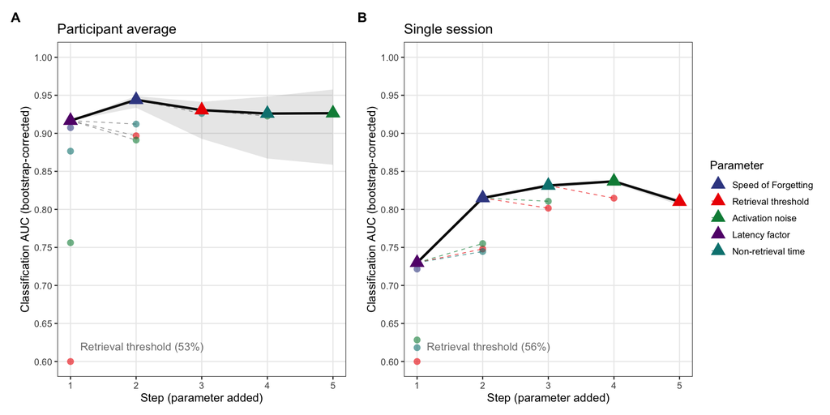

```r
greedy_auc_single <- readRDS(here::here("data", "processed", "fits", "greedy_auc_results_single.rds"))

# Backward compatibility: rename alpha -> phi in cached results
if ("alpha" %in% names(greedy_auc_single$learner_fits)) setnames(greedy_auc_single$learner_fits, "alpha", "phi")
if ("param_added" %in% names(greedy_auc_single$learner_fits)) greedy_auc_single$learner_fits[param_added == "alpha", param_added := "phi"]
if ("param_added" %in% names(greedy_auc_single$summary))      greedy_auc_single$summary[param_added == "alpha", param_added := "phi"]
if ("free_params" %in% names(greedy_auc_single$summary)) {
  greedy_auc_single$summary[, free_params := lapply(free_params, function(fp) replace(fp, fp == "alpha", "phi"))]
}

# ── Panel B: single-session selection path ────────────────────────────────────
summary_single_b <- copy(greedy_auc_single$summary)
summary_single_b[, param_label := param_display[param_added]]

selection_single_b <- summary_single_b[selected == TRUE][order(step)]
selection_single_b[, param_label := param_display[param_added]]

seg_single_b <- summary_single_b[selected == FALSE]
seg_single_b[, y_from := selection_single_b$auc_corrected[
  match(step - 1, selection_single_b$step)
]]

p_auc_single <- ggplot() +
  geom_segment(
    data = seg_single_b[!is.na(y_from)],
    aes(x = step - 1, xend = step, y = y_from, yend = auc_corrected,
        color = param_label),
    linewidth = 0.4, linetype = "dashed", alpha = 0.7
  ) +
  geom_line(data = selection_single_b,
            aes(x = step, y = auc_corrected),
            linewidth = 1.2, color = "black") +
  geom_ribbon(data = selection_single_b,
              aes(x = step, ymin = auc_lo, ymax = auc_hi),
              alpha = 0.15, fill = "grey40") +
  geom_point(data = summary_single_b[selected == FALSE],
             aes(x = step, y = auc_corrected, color = param_label),
             size = 3, shape = 16, alpha = 0.6) +
  geom_point(data = selection_single_b,
             aes(x = step, y = auc_corrected, color = param_label),
             size = 5, shape = 17) +
  geom_text(
    data = summary_single_b[selected == FALSE & auc_corrected < 0.6] %>%
      arrange(auc_corrected) %>%
      mutate(y_pos = 0.62 + seq(0, by = 0.008, length.out = n())),
    aes(x = step + 0.15, y = y_pos,
        label = paste0(param_label, " (",
                       scales::percent(auc_corrected, accuracy = 1), ")"),
        color = 'black'),
    size = 4, hjust = 0, show.legend = FALSE
  ) +
  scale_color_manual(name = "Parameter", values = param_cols) +
  scale_x_continuous(breaks = 1:5) +
  scale_y_continuous(limits = c(0.6, 1),
                     breaks = seq(0.6, 1, by = 0.05),
                     oob = scales::squish) +
  labs(x = "Step (parameter added)",
       y = "Classification AUC (bootstrap-corrected)") +
  theme_bw(base_size = 12) +
  theme(legend.position = "right", panel.grid.minor = element_blank())

# change paramter order for the legend:
p_auc_single <- p_auc_single +
  scale_color_manual(name = "Parameter", values = param_cols,
                     breaks = names(param_cols))
# ── Combine panels ───────────────────────────────────────────────────────────
p_combined <- (p_auc + ggtitle("Participant average")) +
  (p_auc_single + ggtitle("Single session")) +
  plot_annotation(tag_levels = "A") & theme(plot.tag = element_text(size = 14, face = "bold"))

p_combined
```

```r
# Paper Figure 10: greedy parameter selection by bootstrap-corrected AUC (A: participant average, B: single session)
ggsave(here::here("output", "greedy_selection_auc_combined.png"), p_combined,
       width = 11, height = 6, dpi = 300)
```

## Summary statistics for paper

Finally, we print the selection order and the AUCs of all candidates at each step, for both aggregation levels, as reported in Table 4 of the paper.

```r
cat("=== PANEL A: Person-average selection ===\n\n")
```

```
## === PANEL A: Person-average selection ===
```

```r
cat("Selection order:\n")
```

```
## Selection order:
```

```r
greedy_auc$summary[selected == TRUE][order(step),
  .(step, param_added,
    auc_corrected = round(auc_corrected, 3),
    auc_lo = round(auc_lo, 3),
    auc_hi = round(auc_hi, 3))] |> print()
```

```
##     step param_added auc_corrected auc_lo auc_hi
##    <int>      <char>         <num>  <num>  <num>
## 1:     1           F         0.917  0.917  0.917
## 2:     2         phi         0.944  0.934  0.949
## 3:     3         tau         0.930  0.893  0.941
## 4:     4         ter         0.926  0.867  0.948
## 5:     5           s         0.926  0.859  0.958
```

```r
cat("\nAll candidates at each step:\n")
```

```
##
## All candidates at each step:
```

```r
greedy_auc$summary[order(step, -auc_corrected),
  .(step, param_added, selected,
    auc_corrected = round(auc_corrected, 3),
    auc_lo = round(auc_lo, 3),
    auc_hi = round(auc_hi, 3))] |> print()
```

```
##      step param_added selected auc_corrected auc_lo auc_hi
##     <int>      <char>   <lgcl>         <num>  <num>  <num>
##  1:     1           F     TRUE         0.917  0.917  0.917
##  2:     1         phi    FALSE         0.907  0.907  0.907
##  3:     1         ter    FALSE         0.877  0.877  0.877
##  4:     1           s    FALSE         0.756  0.756  0.756
##  5:     1         tau    FALSE         0.532  0.532  0.532
##  6:     2         phi     TRUE         0.944  0.934  0.949
##  7:     2         ter    FALSE         0.912  0.889  0.921
##  8:     2         tau    FALSE         0.897  0.877  0.904
##  9:     2           s    FALSE         0.891  0.860  0.907
## 10:     3         tau     TRUE         0.930  0.893  0.941
## 11:     3           s    FALSE         0.930  0.889  0.948
## 12:     3         ter    FALSE         0.926  0.895  0.937
## 13:     4         ter     TRUE         0.926  0.867  0.948
## 14:     4           s    FALSE         0.923  0.860  0.944
## 15:     5           s     TRUE         0.926  0.859  0.958
```

```r
cat("\n=== PANEL B: Single-session selection ===\n\n")
```

```
##
## === PANEL B: Single-session selection ===
```

```r
cat("Selection order:\n")
```

```
## Selection order:
```

```r
greedy_auc_single$summary[selected == TRUE][order(step),
  .(step, param_added,
    auc_corrected = round(auc_corrected, 3),
    auc_lo = round(auc_lo, 3),
    auc_hi = round(auc_hi, 3))] |> print()
```

```
##     step param_added auc_corrected auc_lo auc_hi
##    <int>      <char>         <num>  <num>  <num>
## 1:     1           F         0.730  0.730  0.730
## 2:     2         phi         0.815  0.814  0.816
## 3:     3         ter         0.831  0.829  0.833
## 4:     4           s         0.837  0.834  0.838
## 5:     5         tau         0.810  0.806  0.813
```

```r
cat("\nAll candidates at each step:\n")
```

```
##
## All candidates at each step:
```

```r
greedy_auc_single$summary[order(step, -auc_corrected),
  .(step, param_added, selected,
    auc_corrected = round(auc_corrected, 3),
    auc_lo = round(auc_lo, 3),
    auc_hi = round(auc_hi, 3))] |> print()
```

```
##      step param_added selected auc_corrected auc_lo auc_hi
##     <int>      <char>   <lgcl>         <num>  <num>  <num>
##  1:     1           F     TRUE         0.730  0.730  0.730
##  2:     1         phi    FALSE         0.722  0.722  0.722
##  3:     1           s    FALSE         0.628  0.628  0.628
##  4:     1         ter    FALSE         0.618  0.618  0.618
##  5:     1         tau    FALSE         0.556  0.556  0.556
##  6:     2         phi     TRUE         0.815  0.814  0.816
##  7:     2           s    FALSE         0.755  0.753  0.756
##  8:     2         tau    FALSE         0.748  0.746  0.749
##  9:     2         ter    FALSE         0.745  0.742  0.746
## 10:     3         ter     TRUE         0.831  0.829  0.833
## 11:     3           s    FALSE         0.811  0.808  0.812
## 12:     3         tau    FALSE         0.802  0.799  0.803
## 13:     4           s     TRUE         0.837  0.834  0.838
## 14:     4         tau    FALSE         0.815  0.810  0.818
## 15:     5         tau     TRUE         0.810  0.806  0.813
```

# Worst-session vs. mean aggregation (Reviewer 2, comment 8)

The classification results above aggregate each participant’s session-level parameter estimates by taking their mean. The reviewer asked whether using the participant’s worst performance instead (or the average of their worst two sessions) might be more sensitive to MCI. To check this, we reuse the already-fitted session-level estimates from the best-performing model (F + $\phi$, step 2 of the person-average selection) and compare four aggregation strategies. No re-fitting is required here, since these parameters are already estimated per session; only the aggregation across sessions changes.

“Worst” is defined in the direction of the paper’s MCI hypotheses: higher $\phi$ (faster forgetting) and higher $F$ (less efficient retrieval) are both expected to indicate greater impairment.

```r
# Per-session F + phi estimates from the best-performing model (step 2)
worst_session_fits <- unique(greedy_auc$learner_fits[
  step == 2 & param_added == "phi",  # value stays "alpha"; only the column was renamed to phi above
  .(user_id, session_id, clinical_status, phi, F = lf)
])

agg_mean <- worst_session_fits[, .(phi = mean(phi), F = mean(F)), by = user_id]

agg_worst1 <- worst_session_fits[, .(phi = max(phi), F = max(F)), by = user_id]

agg_worst2 <- worst_session_fits[, .(
  phi = mean(sort(phi, decreasing = TRUE)[1:min(2, .N)]),
  F   = mean(sort(F,   decreasing = TRUE)[1:min(2, .N)])
), by = user_id]

# Single worst session by a combined (z-scored) phi + F severity index, rather
# than taking each parameter's max independently (possibly from different sessions)
worst_session_fits_z <- copy(worst_session_fits)
worst_session_fits_z[, `:=`(phi_z = scale(phi)[, 1], F_z = scale(F)[, 1])]
worst_session_fits_z[, severity := phi_z + F_z]
agg_worst_session <- worst_session_fits_z[order(user_id, -severity)][, .SD[1], by = user_id][, .(user_id, phi, F)]

aggregation_strategies <- list(
  "Mean across sessions (paper)"       = agg_mean,
  "Worst session, per-parameter max"   = agg_worst1,
  "Mean of worst 2 sessions"           = agg_worst2,
  "Single worst session (joint index)" = agg_worst_session
)

aggregation_results <- rbindlist(lapply(names(aggregation_strategies), function(nm) {
  df  <- merge(aggregation_strategies[[nm]], clinical_df, by = "user_id")
  res <- bootstrap_auc_corrected(df$outcome, df[, .(phi, F)])
  data.table(
    strategy      = nm,
    auc_apparent  = round(res$auc_apparent, 3),
    auc_corrected = round(res$auc_corrected, 3),
    auc_lo        = round(res$auc_lo, 3),
    auc_hi        = round(res$auc_hi, 3)
  )
}))

print(aggregation_results)
```

```
##                              strategy auc_apparent auc_corrected auc_lo auc_hi
##                                <char>        <num>         <num>  <num>  <num>
## 1:       Mean across sessions (paper)        0.633         0.613  0.532  0.642
## 2:   Worst session, per-parameter max        0.613         0.576  0.434  0.618
## 3:           Mean of worst 2 sessions        0.631         0.605  0.509  0.639
## 4: Single worst session (joint index)        0.654         0.622  0.502  0.659
```

```r
saveRDS(aggregation_results, here::here("data", "processed", "fits", "worst_session_aggregation_results.rds"))
```

# Baseline: classification from raw behavioural features (Reviewer 2, comments 5 & 9)

The reviewer asked whether the classification results above (based on the fitted ACT-R parameters) outperform a simpler baseline that relies on the raw behavioural data directly, e.g. mean accuracy and a few RT quantiles. To check this, we compute the same bootstrap-corrected AUC (`bootstrap_auc_corrected()`, defined above) using only raw, model-free behavioural summary statistics: mean accuracy and RT deciles (the 10th–90th percentiles of RT), computed at the participant-average level to match the paper’s headline classification result (F + $\phi$, AUC = .944).

## Compute raw behavioural features

```r
rt_deciles <- seq(0.1, 0.9, by = 0.1)

make_quantile_cols <- function(rt, probs) {
  qs <- quantile(rt, probs)
  names(qs) <- paste0("rt_q", round(probs * 100))
  as.list(qs)
}

# ── Participant-average features (aggregated across all of a participant's sessions) ──
person_behaviour <- d_filtered[, c(
  list(mean_accuracy = mean(correct)),
  make_quantile_cols(rt, rt_deciles)
), by = user_id]

person_behaviour <- merge(person_behaviour, clinical_df, by = "user_id")
```

## Classification AUC from raw behavioural features

```r
decile_cols <- grep("^rt_q", names(person_behaviour), value = TRUE)

feature_sets <- list(
  "Accuracy only"                = c("mean_accuracy"),
  "RT deciles only"               = decile_cols,
  "Accuracy + RT deciles"         = c("mean_accuracy", decile_cols)
)

baseline_auc <- function(df, feature_sets, label) {
  rbindlist(lapply(names(feature_sets), function(nm) {
    cols <- feature_sets[[nm]]
    res  <- bootstrap_auc_corrected(df$outcome, df[, ..cols])
    data.table(
      aggregation   = label,
      feature_set   = nm,
      n_features    = length(cols),
      auc_apparent  = res$auc_apparent,
      auc_corrected = res$auc_corrected,
      auc_lo        = res$auc_lo,
      auc_hi        = res$auc_hi
    )
  }))
}

baseline_results <- baseline_auc(person_behaviour, feature_sets, "Participant-average")

baseline_results[, `:=`(
  auc_apparent  = round(auc_apparent, 3),
  auc_corrected = round(auc_corrected, 3),
  auc_lo        = round(auc_lo, 3),
  auc_hi        = round(auc_hi, 3)
)]

print(baseline_results)
```

```
##            aggregation           feature_set n_features auc_apparent
##                 <char>                <char>      <int>        <num>
## 1: Participant-average         Accuracy only          1        0.833
## 2: Participant-average       RT deciles only          9        0.957
## 3: Participant-average Accuracy + RT deciles         10        0.975
##    auc_corrected auc_lo auc_hi
##            <num>  <num>  <num>
## 1:         0.833  0.833  0.833
## 2:         0.890  0.795  0.951
## 3:         0.895  0.800  0.962
```

```r
saveRDS(baseline_results, here::here("data", "processed", "fits", "baseline_behaviour_auc_results.rds"))
```

Note the gap between `auc_apparent` and `auc_corrected` for the 10-feature model (accuracy + RT deciles): with 10 features predicting only 51 outcomes, the bootstrap correction is doing real work to counteract overfitting, so the corrected AUC is the one that should be compared to the model-based result below, not the apparent one.

## Comparison to the model-based classification result

For reference, the model-based (ACT-R parameter) AUC reported in the text for participant averages is F + $\phi$ = .944 (best model), decreasing slightly to .930–.926 with further parameters added. Comparing this to the raw-behavioural-feature baseline above shows whether the fitted parameters provide a classification advantage over the raw accuracy/RT summary statistics alone.

```r
model_reference <- data.table(
  aggregation = "Participant-average",
  model_auc   = 0.944,
  model_desc  = "F + phi (best step)"
)
print(model_reference)
```

```
##            aggregation model_auc          model_desc
##                 <char>     <num>              <char>
## 1: Participant-average     0.944 F + phi (best step)
```